# Data filtering and analysis in R

Anna Schmoker

4/29/2018

Make sure you have downloaded the **SampleData.csv** file from the homepage https://aschmoke.github.io/Bio381_2018/.

We will be using the following R packages:  
`plyr` `ggplot2` `ggrepel` `patchwork` `reshape2`

### About this data

These data were obtained from a quantitative mass spectrometry experiment that aimed to identify binding partners of the protein PKA-C in mouse fibroblast cells in response to a growth factor. Cells were grown in media containing either light or heavy (stable isotope-labeled) amino acids, under growth factor present or absent conditions. The protein-of-interest (POI) was extracted from the cells using an antibody to the POI, along with any proteins that bound to the POI. Experimental conditions were then combined, digested with a proteolytic enzyme, and subjected to LC-MS/MS. Peptide sequences from the heavy and light conditions were determined using the fragmentation spectra, and mapped to proteins in the mouse proteome. Heavy-to-light ratios give the relative abundance of PKA-C binding partners in growth factor present vs absent conditions.

### Your .csv file

- convert “#” to “+” using a text editor (e.g. BBedit)
- remove spaces from column headers

### What we need to do

1. Filters: high S:N, 3 or more peptides, remove proteins present in the control
2. Normalize H:L ratios to POI, get mean H:L and SD
3. Get a p-value for each protein (sig. increased/decreased binding)
4. Summarize

### Preliminaries

```r
library(plyr)
library(ggplot2)
library(patchwork)
library(ggrepel)
library(reshape2)
```

### Getting your dataset into R

```r
# Read the file
d <- read.table(file="SampleData.csv",header=TRUE,sep=",")

# take a look at it to ensure R is reading the entire file
head(d)
tail(d)
# tail(d)
str(d)
```

### Get some basic stats on the data

```r
# number of rows (peptides) per experimental condition
# A = control
# B = experimental
table(d$SampleID)
```

```
##
##     A     B
## 13953 23954
```

```r
# number of genes (some proteins don't have a "gene symbol"
length(unique(d$GeneSymbol))
```

```
## [1] 1552
```

```r
# Number of unique proteins
length(unique(d$Reference))
```

```
## [1] 1597
```

Take the heavy-to-light ratio out of Log2 space

```r
# Create a new column
# Calculate value based on another value in an existing column
d$Ratio <- with(d, 2^Log2Ratio)
head(d)

# Change number of digits after the decimal
d$Ratio <- round(d$Ratio,4)
head(d)
```

### Subsetting all peptides that meet certain criteria

Require a signal-to-noise ratio > 20

```r
# We need a unique row!
d$Row <- with(d, 1:nrow(d))

# Create a subset of the data that excludes any peptides with a "SumSN" less than 20
# make sure you reference a row with a unique identifier here, otherwise duplicates will be removed
# "create a subset of d, excluding any rows with a unique "Row" designation that has a "SumSN" value less than 20
dSN <- subset(d,!Row %in% Row[SumSN < 20]) # Don't include Row designations that match Rows with a SunSN < 20

# Get new stats
table(dSN$SampleID)
```

```
##
##     A     B
##  9793 17038
```

```r
length(unique(dSN$GeneSymbol))
```

```
## [1] 1025
```

```r
length(unique(dSN$Reference))
```

```
## [1] 1057
```

### Summarize peptide information for each protein

Create a new dataset and summarize using `ddply()` with the `plyr` package For ddply: “If blank, fill with reference” and add something to show that this isn’t the official gene symbol

```r
# Create new dataset from dSN that includes the following
# Reference (existing)
# SampleID (existing)
# GeneSymbol (existing)
# Count = number of peptides per protein
# MeanFC = average H:L Ratio
# StDev = stand deviation H:L Ratio
dMean <- ddply(dSN,.(Reference,SampleID,GeneSymbol),
               summarize,
               Count=length(Reference),
               MeanFC=mean(Ratio),
               StDev=sd(Ratio))
# number of rows and columns
dim(dMean)
```

```
## [1] 1544    6
```

```r
# take a look at the data
head(dMean)
```

```r
# number of proteins
# before
Stat <- length(unique(dSN$Reference)) - length(unique(dMean$Reference))
Stat
```

```
## [1] 0
```

```r
# and after
length(unique(dMean$Reference))
```

```
## [1] 1057
```

```r
# they are the same! Good
```

Now that we have a column with the number of peptides identified per protein, we can filter based on that stat

```r
# We subset again!

dFilt <- subset(dMean,!Reference %in% Reference[Count<3]) # subset excluding proteins identified by less than 3 peptides
dim(dFilt)
```

```
## [1] 701   6
```

```r
length(unique(dFilt$Reference))
```

```
## [1] 442
```

```r
head(dFilt)
```

```
##                  Reference SampleID GeneSymbol Count    MeanFC      StDev
## 1  sp|A2A6Q5-2|CDC27_MOUSE        B      Cdc27     5 1.0267200 0.06689729
## 2    sp|A2A6Q5|CDC27_MOUSE        B      Cdc27   103 1.0021767 0.13987433
## 4     sp|A2AQ07|TBB1_MOUSE        A      Tubb1    21 0.9862000 0.13109783
## 5     sp|A2AQ07|TBB1_MOUSE        B      Tubb1    41 0.9153512 0.17963392
## 7    sp|A6X919|D19L1_MOUSE        B    Dpy19l1     3 0.8622667 0.07009032
## 10    sp|B7ZNG0|KIF7_MOUSE        B       Kif7    11 0.9297545 0.44315082
```

### Remove proteins in control

Filter out all proteins in the control, unless “Count” is 5X higher in the experimental group. 1. subset so only those with both A and B 2. divide B by A 3. subset those that have > 5 in column 4. rbind just distinct B’s and B’s greater than 5X their As 5. Subset data with As removed based on large Bs

```r
# Reshape into 'wide' format for easier manipulation
dFiltWide<-dcast(dFilt, Reference ~ SampleID, value.var = "Count")
head(dFiltWide)
```

```
##                 Reference  A   B
## 1 sp|A2A6Q5-2|CDC27_MOUSE NA   5
## 2   sp|A2A6Q5|CDC27_MOUSE NA 103
## 3    sp|A2AQ07|TBB1_MOUSE 21  41
## 4   sp|A6X919|D19L1_MOUSE NA   3
## 5    sp|B7ZNG0|KIF7_MOUSE NA  11
## 6    sp|E9Q557|DESP_MOUSE NA   5
```

```r
# Extract those that have both A and B in Sample column
dFiltAB<-dFiltWide[which(complete.cases(dFiltWide)),]

# Create column that divides Sample B by A
dFiltAB$mag<-dFiltAB$B/dFiltAB$A

# Subset only those where B is at least 5 times greater than A
dFiltLargeB<-subset(dFiltAB, dFiltAB$mag>=5)

# Get names of those with either A or B
dFiltAorB<-dFiltWide[which(!complete.cases(dFiltWide)),]

# Subset only B samples
dFiltBs<-subset(dFiltAorB, dFiltAorB$B != "NA")

# Create a data frame that have References with either only B or where B > 5x A
namesToSubset<-data.frame(Names=c(as.character(dFiltLargeB$Reference), as.character(dFiltBs$Reference)))

dFilt$Reference<-as.character(dFilt$Reference)

# Subset original data to only include References that have B samples
dFiltBs<-subset(dFilt, dFilt$Sample=="B")
dFiltNew<-subset(dFiltBs, dFiltBs$Reference %in% namesToSubset$Names)

head(dFiltNew)
```

```
##                  Reference SampleID GeneSymbol Count    MeanFC      StDev
## 1  sp|A2A6Q5-2|CDC27_MOUSE        B      Cdc27     5 1.0267200 0.06689729
## 2    sp|A2A6Q5|CDC27_MOUSE        B      Cdc27   103 1.0021767 0.13987433
## 7    sp|A6X919|D19L1_MOUSE        B    Dpy19l1     3 0.8622667 0.07009032
## 10    sp|B7ZNG0|KIF7_MOUSE        B       Kif7    11 0.9297545 0.44315082
## 11    sp|E9Q557|DESP_MOUSE        B        Dsp     5 0.0760200 0.02037675
## 12   sp|E9Q634|MYO1E_MOUSE        B      Myo1e     5 1.0626600 0.05190008
```

With an average Ratio for each protein, we can normalize to a loading control

```r
# First we need to find the Ratio for our loading control
# Save the Prkaca "Ratio" in "norm"
norm <- dFiltNew$MeanFC[dFiltNew$GeneSymbol=="Prkaca"]
norm
```

```
## [1] 0.978076
```

```r
# Now we can create a new column in the dFilt data frame with a mean fold change (Ratio) normalized to that of Prkaca, our loading control
dFiltNew$FCnorm <- with(dFiltNew, MeanFC/norm)
head(dFiltNew)
```

### Get a p-value & FDR for each binding partner

With a normalized fold change and standard deviation, we can get a p-value for each Prkaca binding partner to determine which proteins have a H:L Ratio that is significantly different from Prkaca.

If you only have two populations to compare, a simple t-test is easy to conduct using the `t.test()` function in R. However, I couldn’t figure out a way to use this function to test the mean Ratio in each row against that for Prkaca, so I had to manually calculate this for each row…

```r
# Save Prkaca stats to use in the formula
mNorm <- dFiltNew[dFiltNew$GeneSymbol=="Prkaca","FCnorm"]
mNorm
```

```
## [1] 1
```

```r
sNorm <- dFiltNew[dFiltNew$GeneSymbol=="Prkaca","StDev"]
sNorm
```

```
## [1] 0.0689932
```

```r
nNorm <- dFiltNew[dFiltNew$GeneSymbol=="Prkaca","Count"]
nNorm
```

```
## [1] 25
```

```r
# Create a new column for the p-value
dFiltNew$pVal <- with(dFiltNew,
                   2*pt(
                     -abs(
                       ((FCnorm - mNorm)/
                          sqrt((((Count-1)*StDev^2 + (nNorm-1)*sNorm^2)/
                                  (Count+nNorm-2))*(1/Count+1/nNorm)))),
                     (Count + nNorm - 2)),lower=FALSE)
# pt() gives the probability distribution of the student t dist. To get the p-value, we need to multiply the pt() output by two. Futher, if the t value is positive, we need to use 1-t as input. We can get around this by taking the -abs(t).
```

Calculate FDR and make other adjustments

```r
# Adjust p-value for multiple calculations
dFiltNew$FDR <- p.adjust(dFiltNew$pVal,method="BH")

# Log2-transform the normalized fold change
dFiltNew$Log2FCnorm <- with(dFiltNew, log(FCnorm,2))

# Log10-transform the FDR (for data visualization)
dFiltNew$LogFDR <- with(dFiltNew, -log(FDR,10))
dim(dFiltNew)
```

```
## [1] 182  11
```

### Create volcano plot to visualize distribution of FDR values and fold change for each protein

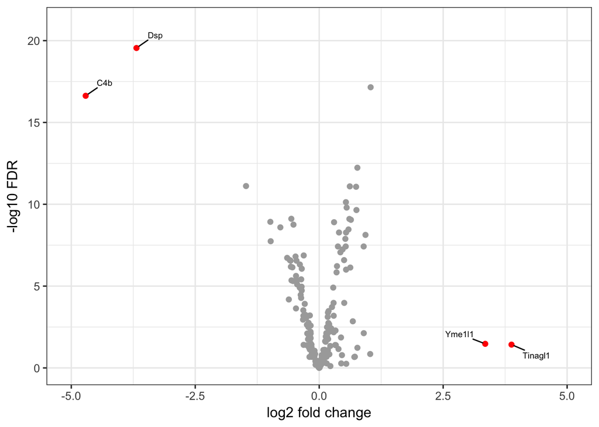

```r
# Create new column to denote which proteins meet a certain threshold
# Use to highlight those with an absolute fold change > 4 and a p-value < 0.05
dFiltNew$threshold <- as.factor(abs(dFiltNew$Log2FCnorm) > 2 &
                                  dFiltNew$FDR < 0.05)

# Construct the plot
p1 <- ggplot(data=dFiltNew, aes(x=Log2FCnorm, y=LogFDR, color=threshold)) +
  xlim(c(-5, 5)) + ylim(c(0, 21)) +
  xlab("log2 fold change") + ylab("-log10 FDR") +
  geom_point(size=1.75) +
  scale_color_manual(values = c("darkgrey", "red")) +
  theme_bw(base_size = 12) +
  theme(legend.position = "none") +
  geom_text_repel(data=subset(dFiltNew,FDR < 0.05 &
                                  abs(Log2FCnorm) > 2),
                    aes(label = GeneSymbol),
                    size = 2.5,
                    color="black",
                    box.padding = unit(0.35, "lines"),
                    point.padding = unit(0.3, "lines"))
p1
```

### Create Rank-ordered plot of log2 ratios

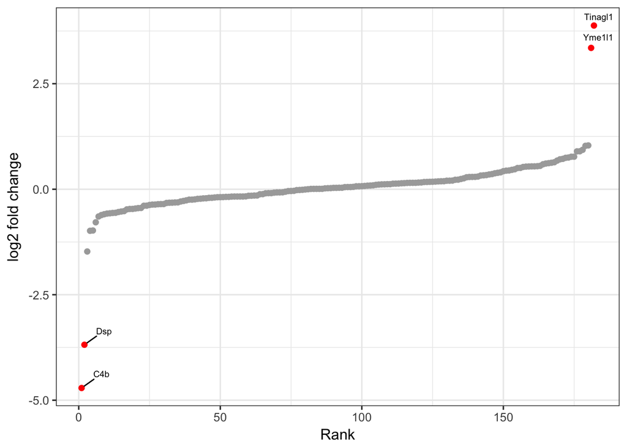

```r
# order rows by Log2-transformed mean fold change
dFiltNew <- dFiltNew[order(dFiltNew$Log2FCnorm),]

# add rank order based on Log2Ratio
dFiltNew$Rank <- with(dFiltNew, 1:nrow(dFiltNew))


p2 <- ggplot(data=dFiltNew,mapping=aes(x=Rank,y=Log2FCnorm,color=threshold)) +
  xlab("Rank") + ylab("log2 fold change") +
  geom_point(size=1.75) +
  scale_color_manual(values = c("darkgrey", "red")) +
  theme_bw(base_size = 12) +
  theme(legend.position = "none") +
  geom_text_repel(data=subset(dFiltNew,FDR < 0.05 &
                                abs(Log2FCnorm) > 2),
                  aes(label = GeneSymbol),
                  size = 2.5,
                  color="black",
                  box.padding = unit(0.35, "lines"),
                  point.padding = unit(0.3, "lines"))
p2
```

### Create histogram of Log2 ratios

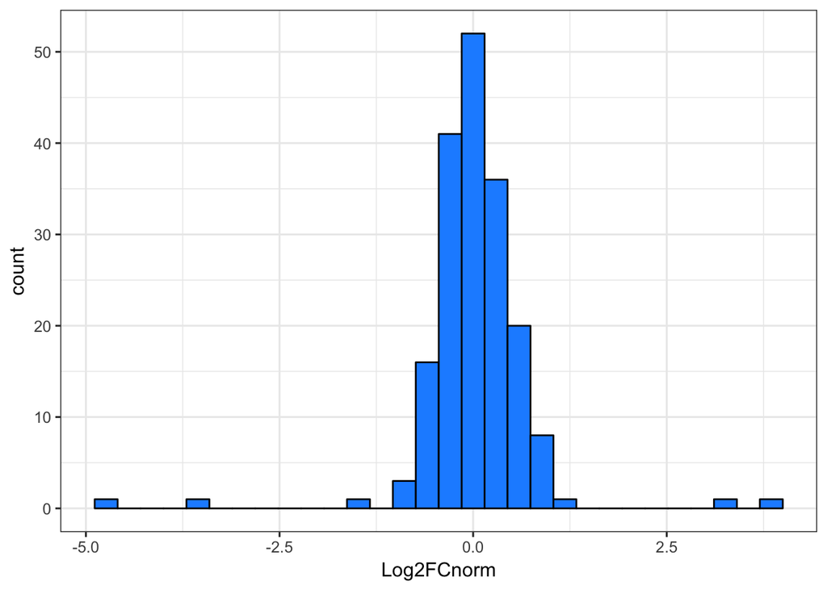

```r
p3 <- ggplot(data=dFiltNew,mapping=aes(Log2FCnorm,fill=I("dodgerblue"), color=I("black"))) +
  geom_histogram() +
  theme_bw(base_size = 12)
p3
```

### Plot together

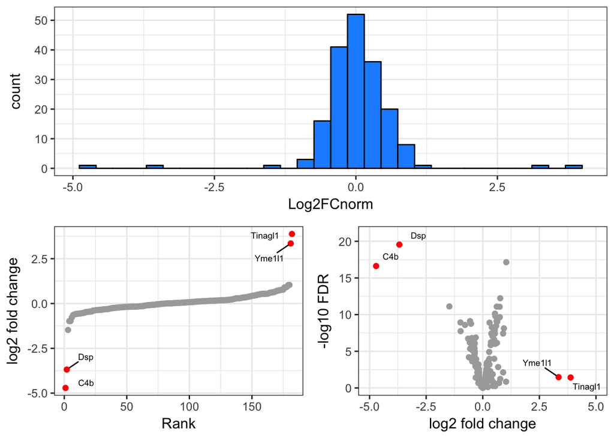

```r
p3 + {
  p2 +
    p1 +
    plot_layout(nrow=1)
} +
  plot_layout(ncol=1)
```